# Data Science Capstone - Slide deck

Larry Lugo, M.Sc.  
November, 2015

# Using Sentiment Analysis and Collaborative Filtering methods to predict the review's rating based on its text alone from Yelp 2015 data set

### 1. Introduction and background

- Collaborative Filtering has been mostly focusing on the information resource of explicit user numerical ratings feedbacks.
- The ever-growing availability of textual user reviews has become an important information resource.
- This information rich resource of textual reviews have clearly exhibited brand-new approaches to solving many of the important problems that have been perplexing the research community for years, such as the explanation of recommendation and the automatic generation of user or item profiles.
- Where a wealth of explicit product attributes/features and user attitudes/sentiments are expressed therein.
- The fundamental importance of textual reviews has gained wide recognition, mainly because of the difficulty in formatting, structuring and analyzing the free-texts.
- In this Data Science Capstone project, Sentiment Analysis of textual reviews and Collaborative Filtering were combined under a mixed approach to predict the review's rating on Yelp 2015 data set.

### 2. Methods and data

- Yelp offers a rich set of data for research and educational purposes
- One of the questions in this year's challenge is “How well can you guess a review's rating from its text alone?”
- To answer this question the following method was applied: (i) Based on the Yelp磗 5-star rating system, a negative feeling was considered when the review was 2 or less stars. Then, (ii) Text mining methods and a CART (Classification and regression trees) model were applied using R to predict negative or positive (3 or more stars) sentiment in the review.
- The review file has 1.569.264 registers. Due to hardware limitations, it was impossible to process the whole information
- A random sample of 25% (392.316 reviews.) was taken to ensure an accurate representation of the total data set .
- A Text Mining was done: (i) creating the corpus using “text” written by users; (ii) cleaning the data through convert text to lower case, remove punctuation and stop words. (iii) Stem the corpus. (iv) Create a Document Term Matrix. (v) Delete sparse terms with 5% or less of frequency. (vi) Matrix was converted to data frame to build a CART model
- “Negative” was created: TRUE if user gives 2 or less stars. FALSE is 3 or more stars are given.

```r
# SAMPLING: Take a 25% sample = 392,316 records
projData25 <- projData[sample(1:nrow(projData), 392316, replace=FALSE),]
str(projData25)
```

```
'data.frame':   392316 obs. of  3 variables:
 $ stars   : int  3 1 5 4 1 5 5 4 5 3 ...
 $ text    : chr  "I had my very first Red velvet cake when I was 16. It was a gift from a friend. It was my first experience with Barbs Bakery. I"| __truncated__ "They don't take reservations and the hostess was rude and also inept. She seated a party of 2 at a 6 top table which meant the "| __trun…
 $ negative: Factor w/ 2 levels "FALSE","TRUE": 1 2 1 1 2 1 1 1 1 1 ...
```

### 3. Results

```r
predictCART = predict(sparse5CART, newdata=testsparse5, type="class")
table(testsparse5$Negative, predictCART)
```

```
       predictCART
        FALSE  TRUE
  FALSE 93791  1476
  TRUE  19923  2505
```

```r
printcp(sparse5CART)
```

```
Classification tree:
rpart(formula = Negative ~ ., data = trainsparse5, method = "class")

Variables actually used in tree construction:
[1] great love  told

Root node error: 52332/274621 = 0.19056

n= 274621

        CP nsplit rel error  xerror      xstd
1 0.018268      0   1.00000 1.00000 0.0039329
2 0.011160      2   0.96346 0.96346 0.0038769
3 0.010000      3   0.95230 0.95645 0.0038659
```

### 4. Results (continue) and Discussion

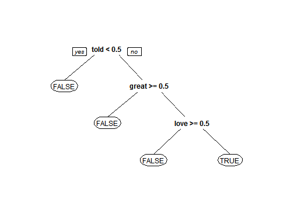

```r
prp(sparse5CART)
```

5.Discussion

Using 25% of data Review, near four hundred thousand opinions, it was posible to develop a CART model to predict the user磗 sentiment regarding their experience in different kind of business.

Sampling is really effective when there are hardware, time or economic limitations that makes imposible to analyze the whole data in huge files. To avoid this kind of limitations, technology like Hadoop or other server based technology could be used.